# mapping boston crime data

```r
bos_crime %>% group_by(INCIDENT_NUMBER) %>% mutate(count=n()) %>% select(INCIDENT_NUMBER,count, DISTRICT,OFFENSE_CODE) -> inc_num
table(inc_num$count,inc_num$DISTRICT)
```

```
              A1   A15    A7    B2    B3   C11    C6   D14    D4   E13   E18    E5 External
  1   2009 42895  8727 17017 61379 45243 53216 29582 26982 50573 22532 23477 17629      133
  2    254  6332   850  1930 10962  7816  8508  3776  2942  7810  3008  2698  2408        0
  3     75  2433   255   600  3330  1806  2460  1161   693  2436   930   666   540        0
  4     72  1268    84   188  1340   792  1060   456   224  1048   388   284   204        0
  5     15   575    30   100   560   280   485   155    85   420   160   105    50        0
  6      0   222    12    30   300   138   210    36    24   180    54    54    24        0
  7      7   119     7    14    91    14    49    28     7    56    21    35     0        0
  8      0    48     0     8    48    24    48     0     0    32     8     8     0        0
  9      0    36     0     0     9    18     0     9     0     0     9    18     9        0
  10     0     0     0     0    20    20    30     0     0    20    10     0    10        0
  11     0     0     0     0    22     0     0     0    11    11     0     0     0        0
  12     0     0     0     0    36     0     0     0     0    24     0     0     0        0
  13     0     0     0     0     0    13    13     0     0     0     0     0     0        0
  14     0     0     0     0    14     0     0     0    14     0     0     0     0        0
  15     0     0     0     0     0    15     0     0     0     0     0     0     0        0
  18     0     0     0     0     0     0     0     0     0    18     0     0     0        0
  20     0     0     0     0    20     0     0     0     0     0     0     0     0        0
```

The above table groups incidents by incident number and then by district. The y axis of the table denotes the number of codes applied to a single incident. The original hypothesis for the repeat rows was that each charge/offense code generated a new observation for the same event. Assuming that, we can group the data further by both incident_number and offense_code. The results show a very uneven distribution. So what does this actually show? These data (below) represent the number of entries where there is more than one specific charge per incident.

```r
inc_num %>% filter(count>19) %>% head()
```

[output not shown]

```r
NA
```

```r
bos_crime %>% group_by(INCIDENT_NUMBER,OFFENSE_CODE) %>% mutate(count=n()) %>% select(INCIDENT_NUMBER,count, DISTRICT,OFFENSE_CODE) -> inc_num
table(inc_num$count,inc_num$DISTRICT)
```

```
             A1   A15    A7    B2    B3   C11    C6   D14    D4   E13   E18    E5
  1   483 10824  1987  4049 15738 11174 13757  6909  6273 12975  5599  5192  4196
  2     0    14     0     6    60    22    34    12     4    22     8    10     6
  3     0     3     3     0     9     3     9     3     0     9     3     3     0
  4     0     4     0     0    12     0     0     0     0     4     0     0     0
  5     0     0     0     0     0     5     0     0     0     0     0     0     0
  6     0     0     0     0     0     0     0     0     0     6     0     0     0
```

```r
round(prop.table(table(inc_num$count,inc_num$DISTRICT),margin=2)*100,2)
```

```
               A1    A15     A7     B2     B3    C11     C6    D14     D4    E13    E18     E5
  1 100.00  99.81  99.85  99.85  99.49  99.73  99.69  99.78  99.94  99.69  99.80  99.75  99.86
  2   0.00   0.13   0.00   0.15   0.38   0.20   0.25   0.17   0.06   0.17   0.14   0.19   0.14
  3   0.00   0.03   0.15   0.00   0.06   0.03   0.07   0.04   0.00   0.07   0.05   0.06   0.00
  4   0.00   0.04   0.00   0.00   0.08   0.00   0.00   0.00   0.00   0.03   0.00   0.00   0.00
  5   0.00   0.00   0.00   0.00   0.00   0.04   0.00   0.00   0.00   0.00   0.00   0.00   0.00
  6   0.00   0.00   0.00   0.00   0.00   0.00   0.00   0.00   0.00   0.05   0.00   0.00   0.00
```

```r
bos_crime %>% filter(INCIDENT_NUMBER=="I152071596") %>% head()
```

[output not shown]

```r
NA
```

[figure not shown]

```r
table(inc_num$count,inc_num$DISTRICT) %>% as.data.frame() -> i_n

names(i_n)[1]<-"diff_codes"
names(i_n)[2]<-"district"

i_n$over2<-ifelse(as.numeric(i_n$diff_codes)>6,1,0)
i_n$over2<-factor(i_n$over2,levels=c(1,0),labels=c("over 2","2 or under"))


i_n %>%
  filter(!is.na(district) & district!="" & district!="External") %>%
  filter(Freq!=0) %>%
  ggplot(aes(x=Freq,y=diff_codes,color=district))+
  geom_point()+
  ylab(label="number of rows per incident number")+
  labs(title = "Distribution of multiple code application across district",
       subtitle ="Source: BPD")
```

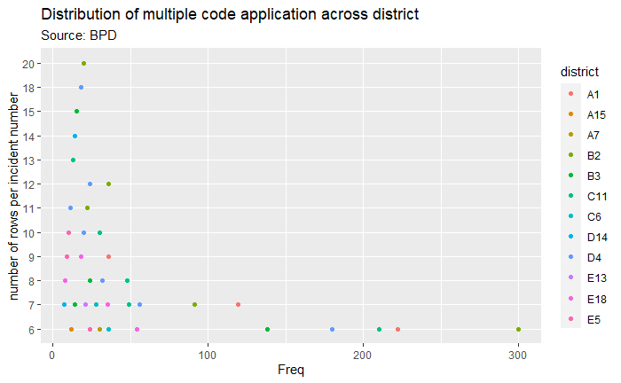

```r
i_n %>%
  filter(!is.na(district) & district!="" & district!="External") %>%
  filter(Freq!=0) %>%
  filter(as.numeric(diff_codes)>5) %>%
  ggplot(aes(x=Freq,y=diff_codes,color=district))+
  geom_point()+
  ylab(label="number of rows per incident number")+
  labs(title = "Distribution of multiple code application across district",
       subtitle ="Source: BPD")
```

```r
NA
NA
NA
```